# Muestreo Estadístico

Semana 1: Introducción, decisiones previas, definiciones y estrategia muestral

Giovany Babativa-Márquez, PhD

jgbabativam@unal.edu.co

## Sobre Mi

PhD en Estadística, MSc en Big Data, MSc en Estadística y Estadístico. Con 25 años de experiencia profesional y docente, director de analítica en varias empresas, miembro del comité de expertos en pobreza en el DANE y consultor de la División de Estadística de la CEPAL. Ex-decano de la Facultad de Estadística USTA, ex-director de operaciones en el ICFES,…

> Puedes encontrarme en:
- [Google scholar](https://scholar.google.es/citations?user=2NJRNg8AAAAJ&hl=es)
- [GitHub. https://github.com/jgbabativam](https://github.com/jgbabativam)
- [linkedin](https://www.linkedin.com/in/giovany-babativa-marquez/?originalSubdomain=co)
- jgbabativam@unal.edu.co

## Presentación

- Nombres.
- Materias que tiene inscritas.
- Ya aprobó:
  - Programación
  - Probabilidad
  - Inferencia

## Reglas del juego

- Horario: Martes y Jueves de 4:00 p.m. a 5:45 p.m.
- Mecanismo de evaluación:
  - 3 exámenes.
  - 1 exposición pública.
  - Tareas
- Temas de exposición y grupos de trabajo.
- Bibliografía

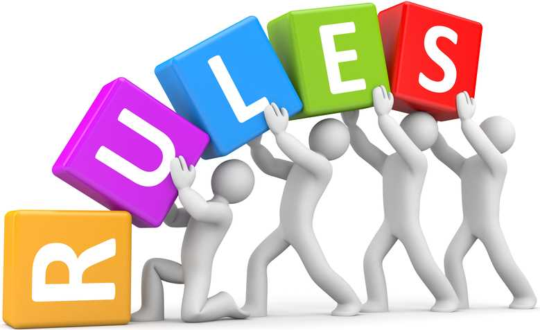

## Proceso de analítica

[Wickham, H. y otros (2023)](https://r4ds.hadley.nz/)

## Paquete R

- Paquete de uso libre
- Tiene todos los métodos que necesitamos
- Incluye paquetes específicos en muestreo como `TeachingSampling`, `samplesize4surveys`, `survey`, `srvyr`, `sampling`, etc

[figure not shown]

## Etapas del proceso

[figure not shown]

## El entorno `tidyverse`

[figure not shown]

## Flujo de trabajo

[figure not shown]

# ANTECEDENTES Y JUSTIFICACIÓN

## Sir Francis Galton (1822-1911)

- **Galton** hizo importantes contribuciones en muchos campos de la ciencia, incluyendo la meteorología (mapas meteorológicos), la estadística (regresión y correlación), la psicología (sinestesia), la biología (mecanismo de la herencia) y la criminología (huellas dactilares).
- Fue el primero en introducir el uso de cuestionarios y encuestas para recopilar datos sobre comunidades humanas.

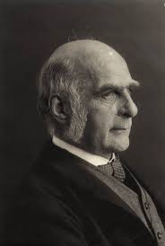

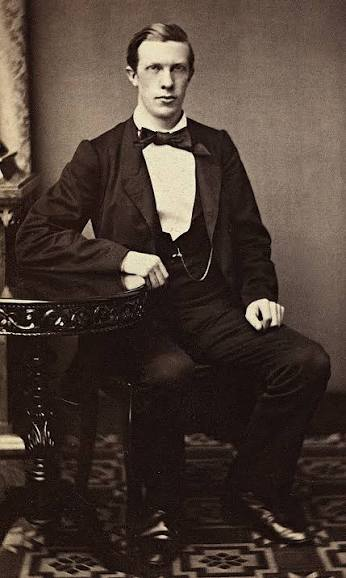

Anders N. Kiær (1838–1919)

- Fundador y primer director del Instituto de Estadística de Noruega.
- Primero en usar una encuesta por muestra en lugar de un censo completo.
- En el ISI de Berna (1895) presentó el **método representativo**: una “investigación parcial” cuidadosamente elegida para reflejar a la población en miniatura.
- Su noción de “representatividad” era subjetiva y sin base probabilística — la comunidad estadística de la época lo recibió con fuerte oposición.

## 1906-1926 — Bowley: aleatorización y estratificación

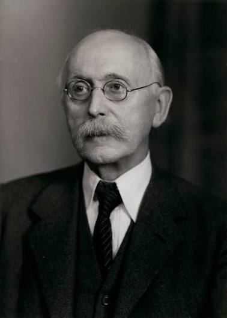

Arthur L. Bowley (1869–1957)

- Lucien March (1903) sugiere la **aleatorización** como base objetiva; Bowley (1906) la justifica teóricamente y (1912) demuestra su viabilidad en la encuesta de Reading.
- **ISI Roma (1925):** resolución que acepta el muestreo, dejando a discreción del investigador usar selección aleatoria o intencional.
- Bowley (1926) introduce la noción de **estratos**: agrupar unidades similares con afijación proporcional.

## Jerzy Neyman (1894-1981)

- Introdujo las reglas de probabilidad en la selección de muestras.
- Neyman, J.(1934). On the two different aspects of the representative method: The method of stratified sampling and the method of purposive selection, Journal of the Royal Statistical Society: Series B, 97 (4), 557–625.

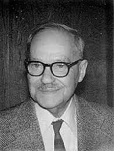

## Jerzy Neyman (1894-1981)

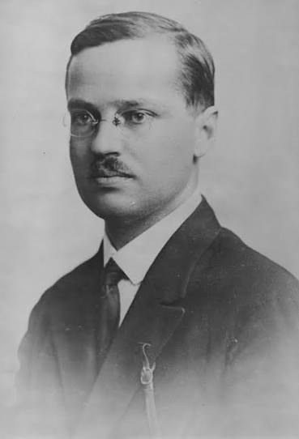

Jerzy Neyman (1894–1981)

Introdujo el muestreo bajo las leyes de la **PROBABILIDAD** haciendo grandes contribuciones al muestreo

1. Marco muestral.
2. Tamaño de la muestra en muestreos estratificados.
3. Muestreo de conglomerados.
4. Estimación de la varianza.

## William Edwards Deming (1900 - 1993)

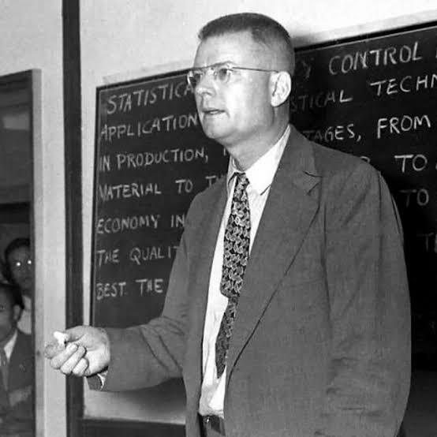

W. E. Deming (1900 - 1993)

- Deming escucha a Neyman en Londres (1936) y lo lleva a enseñar a los estadísticos del gobierno de EE. UU.
- Censo de EE. UU. (1940): Deming y Hansen diseñan una submuestra del 5% con cuestionario largo.

## Morris Hansen (1910-1990)

- Implementó los diseños de muestreo en la Oficina del Censo y la Oficina de Estadísticas Laborales de EEUU.
- Pionero en establecer el Muestreo de Encuestas como un estándar de excelencia para la recolección de datos en agencias gubernamentales.
- Olkin, I. (1987). Una conversación con Morris Hansen. *Statistical Science* 2, 162-179

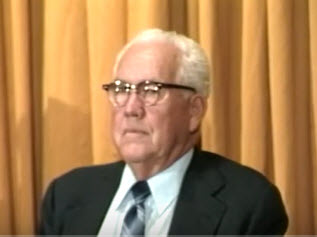

## ¿Por qué hacer muestreo?

- Reducción de costos (eficiencia).
- Obtener información rápida (tiempo).
- En ocasiones es la única forma de obtener información (procesos de control de calidad).
- ¿Cualquier muestra es buena?. ¿Es suficiente con que la muestra sea muy grande?
- Para usted, ¿cuál es un tamaño de muestra adecuado?, ¿cuáles cree que son los factores que afectan el tamaño de muestra?

## Temas que se alcanzan en este curso

- Conceptos básicos en el muestreo probabilístico
- Muestreo Aleatorio Simple
- Uso de información auxiliar: Muestreo Sistemático, PPT, $\pi$PT, estratificado.
- Estimadores de Horvitz-Thompson y Hansen-Hurwitz
- Estimación de la incertidumbre
- Muestreo por conglomerados y de varias etapas

## Temas que NO se alcanzan a ver en este curso

- Estrategias de estratificación
- Métodos de calibración
- Ajustes por la ausencia de respuesta
- Estimación de la varianza usando métodos replicados
- Diseños de muestreo en evaluaciones de impacto o de resultados
- Modelos de estimación en áreas pequeñas (SAE)
- Integración de datos usando MP y NP

**Muestreo Estadístico** — Universidad Nacional de Colombia

© 2026 Giovany Babativa-Márquez, PhD. Todos los derechos reservados.

Material elaborado con fines académicos para el curso de Muestreo Estadístico. Se basa principalmente en Särndal, C.-E., Swensson, B. & Wretman, J. (1992). *Model Assisted Survey Sampling*. Springer. Prohibida su reproducción total o parcial con fines comerciales sin autorización expresa del autor.